# Math 120 Week 01

Prof Miller

25 January, 2020

# Tuesday

## I write most of our notes in RStudio

This will be posted online in its entirety. I’ll update it in the afternoon after each class period.

Don’t worry about taking word-for-word notes. You’re not a stenographer! Instead, summarize your thoughts and reactions to help you study later.

I’ll also use the board for notes sometimes. **Be sure to incorporate boardwork into your written notes!!**

## Goals for Tuesday:

- What is a dataset?
- What do we want to say about data?

Example: the built-in `mpg` dataset. It’s about cars.

```r
head(mpg)
```

| manufacturer | model | displ | year | cyl | trans | drv | cty | hwy | fl | class |
| --- | --- | --- | --- | --- | --- | --- | --- | --- | --- | --- |
| audi | a4 | 1.8 | 1999 | 4 | auto(l5) | f | 18 | 29 | p | compact |
| audi | a4 | 1.8 | 1999 | 4 | manual(m5) | f | 21 | 29 | p | compact |
| audi | a4 | 2.0 | 2008 | 4 | manual(m6) | f | 20 | 31 | p | compact |
| audi | a4 | 2.0 | 2008 | 4 | auto(av) | f | 21 | 30 | p | compact |
| audi | a4 | 2.8 | 1999 | 6 | auto(l5) | f | 16 | 26 | p | compact |
| audi | a4 | 2.8 | 1999 | 6 | manual(m5) | f | 18 | 26 | p | compact |

Generally, we’ll always work with “tidy” data. A tidy dataset is a grid/matrix/rectangle/table of data that satisfies:

- Every row is an “observation” or “case”. In mpg: each case is a specific car!
- Every column is a variable, i.e. a specific quality of our observations.
- Each cell contains exactly one measurement

Even if we have tidy data, it’s still hard (sometimes) to understand what it means!

Answer: metadata. Metadata is “data about data”. It explains cases, variables, and units.

## Types of data

Different kinds of data require different tools to analyze! Gotta know!

BIG DIVIDE: number or not. Each can be subdivided.

Quantitative data can be discrete or continuous.

**Discrete**: Whole units. Countable!!!!! Ex: number of siblings. Can’t have 3.65 siblings. Messy.

**Continuous**: Can take any value on the real line. Usually, these are physical measurements: height, length, duration, volume, etc etc. Infinite decimals. Example, height: someone could be 5’6“, someone could 5’7”, and there are an infinite number or possibilities between.

Categorical data can also be divided into two kinds:

**Nominal**: No natural ordering. Ex: hair color, nationality.

**Ordinal**: There is a natural, intrinsic ordering.

- Age: it counts something. Probably discrete, not ordinal.
- Year in school: fresh, soph, jun, sen. Natural order.
- Clothing size: S, M, L, XL Natural order.
- Month of the year: Jan, Feb, March….. natural order. ordinal.

## Notes about `mpg` data

- “Year” is ordinal. Even though they’re numbers, just a label. Like month or day of the week. It is a little blurry! In some sense, similar to discrete.
- Note for `cty` and `hwy`: Decide discrete vs continuous by what they *are*, not how we rounded. These are **continuous**!

## What do we say about data?

Always first: visualize!!! Warning: the options for visualization depend on the type of data!

## Quantitative visualization: histograms

Example: let’s make a histo of the hwy variable from the `mpg` dataset.

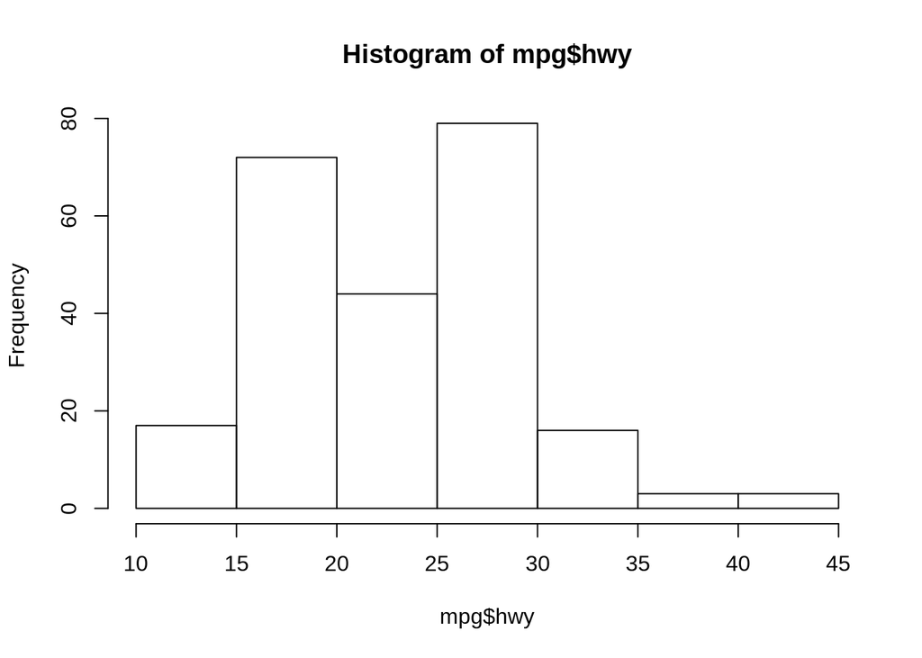

```r
#note:  $ choooses variable

hist( mpg$hwy )
```

Observations:

- Bimodal. Two groups: one less efficient, one more.
- Right skew (right tail). I.e., most cars have relatively low mpg, and only a few have very high mpg.
- What’s “normal”? Looks like 25ish is a normal mpg.
- Spread? Variability? All are btwn 10mpg and 45mpg. Most are between 15 and 35mpg.

Important caveat about historgrams: the number of bins/breaks is up to you! Changing the breaks can really change the shape of the histo!

Example: 15 breaks

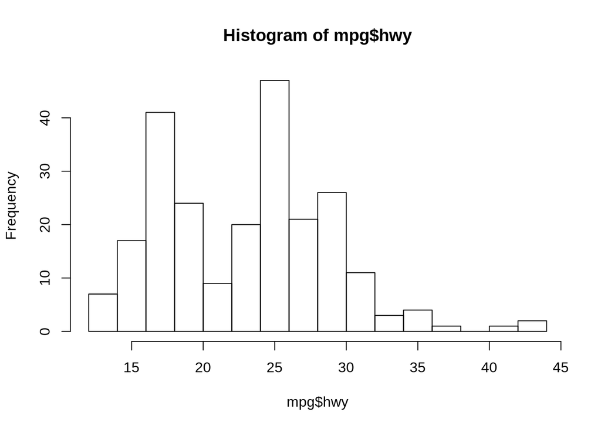

```r
hist( mpg$hwy, breaks=15)
```

Human feelings: we can see bimodal more clearly. Maybe outliers? Generally, more info, good.

Example: breaks = 4

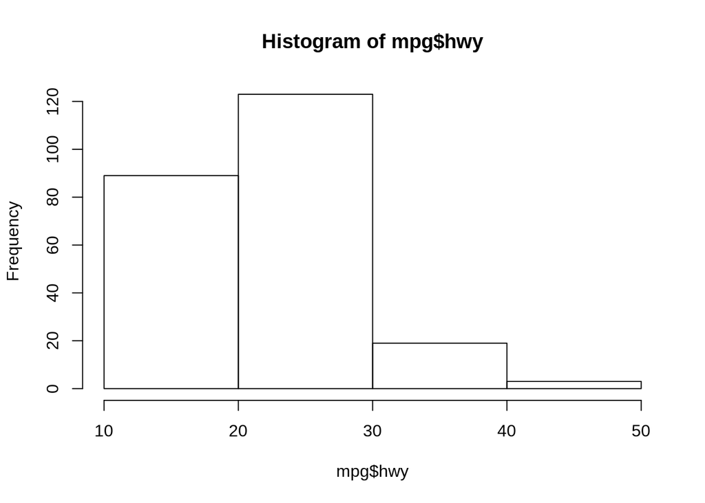

```r
hist(mpg$hwy,breaks = 4)
```

Feelings: we get different info about the shape. Lose info about bimodal feature. (Bad!) Do get an overall feel of shape (good).

Example: 200 breaks

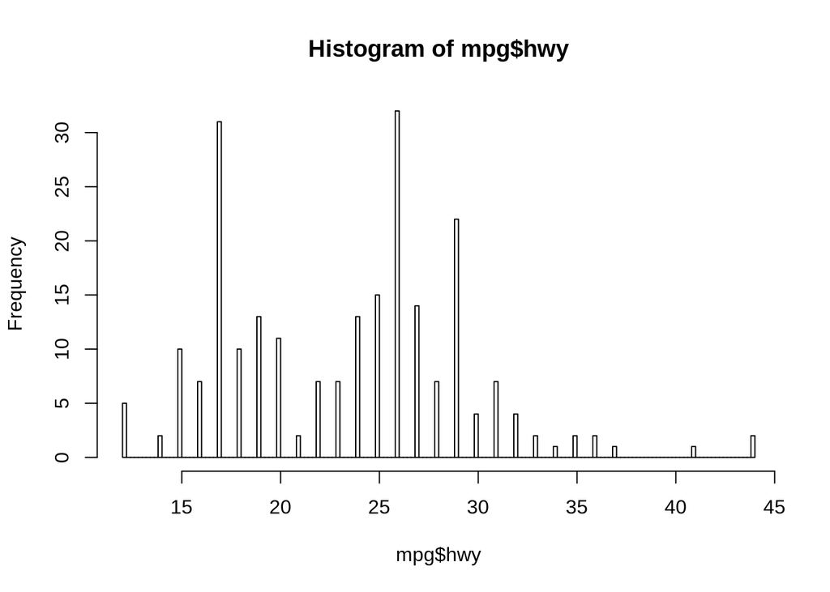

```r
hist(mpg$hwy, breaks=200)
```

Here, we’re really seeing each specific outcome. Probably too much!  
Moral of the story: there’s no right number. Play around! Use the breaks that best show your pattern.

## Visulalizing Categorical Data

Main tool: barplot. Like a histo, but for categorical data.

Example: take a look at class (suv, pickup, etc)

First: table

```r
table(mpg$class)
```

```
##
##    2seater    compact    midsize    minivan     pickup subcompact
##          5         47         41         11         33         35
##        suv
##         62
```

Visualize with a barplot:

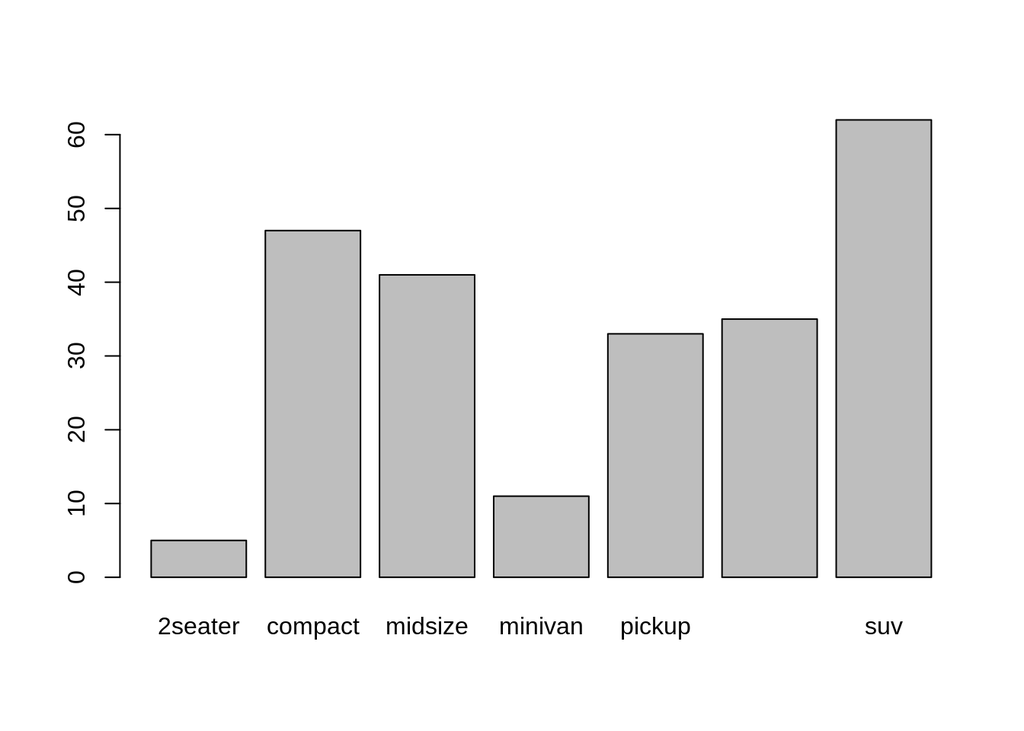

```r
barplot( table( mpg$class))
```

We can compare the proportions of each easily with a barplot.

Warning: It doesn’t make sense to talk about shape or center or spread for categorical variables!

Also, there’s no notion of “breaks” or “bins”, a barplot has a completety determined x-axis: one bar for each “level” of the category.

## Relationships between quantitative variables

First, quantitative data: use “scatterplot”. It’s an x-y plot of all pairs of points from two variables.

Example: is there a relationship between hwy and cty mpg?

In r, the command is “plot”.

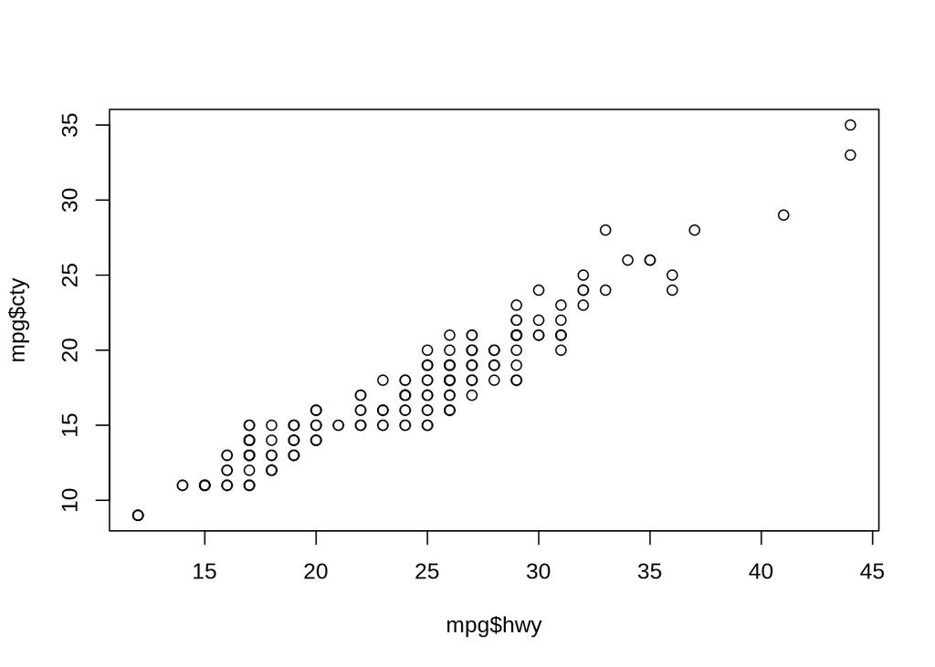

```r
plot( mpg$hwy, mpg$cty )
```

Human feelings: strong relationship! As hwy fuel efficiency increases, so does cty. Seems like predict one from the other! Positive relationship.

Example: x= displacement vs y= cty mpg.

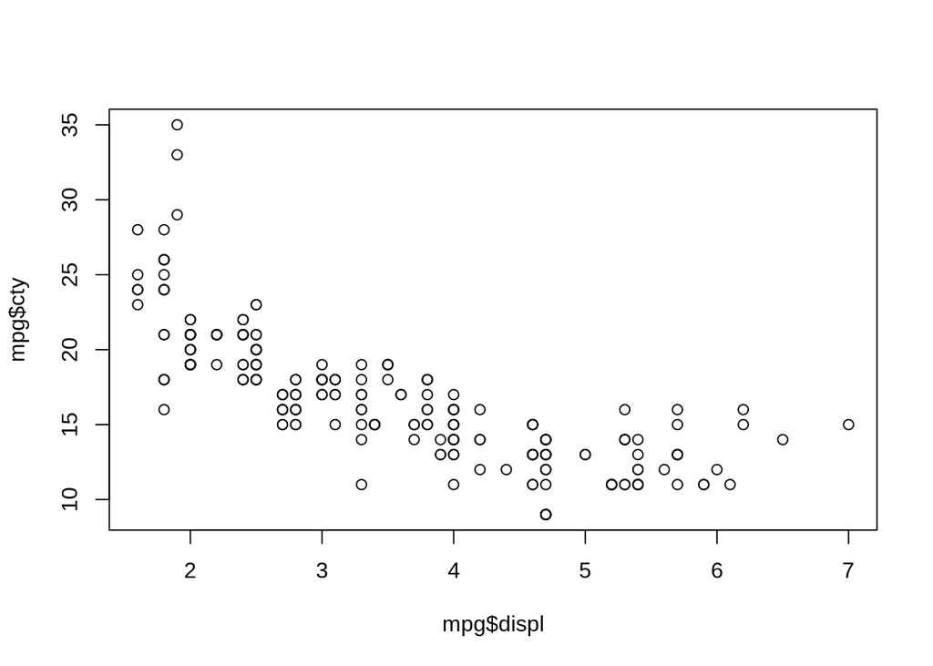

```r
plot( mpg$displ, mpg$cty)
```

Human feelings: we see a predictable drop in fuel efficiency as displacement increasea. Mabye not quite a linear a relationship as hwy vs cty.

## Visualizing relationship with categorical data

Kinda tougher. Main tool: contingency tables and stacked barplots.

Easy in R. Example: Let’s compare drive type (drv) with class.

```r
table(mpg$drv, mpg$class)
```

```
##
##     2seater compact midsize minivan pickup subcompact suv
##   4       0      12       3       0     33          4  51
##   f       0      35      38      11      0         22   0
##   r       5       0       0       0      0          9  11
```

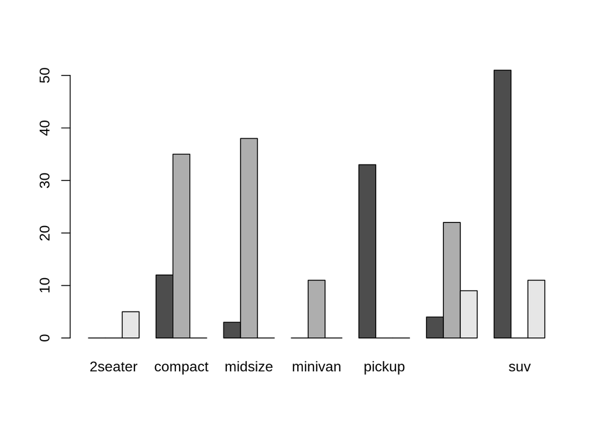

```r
# Note:  <- stores a variable

counts <- table(mpg$drv, mpg$class)

barplot(counts, beside = TRUE)
```

You can choose the order

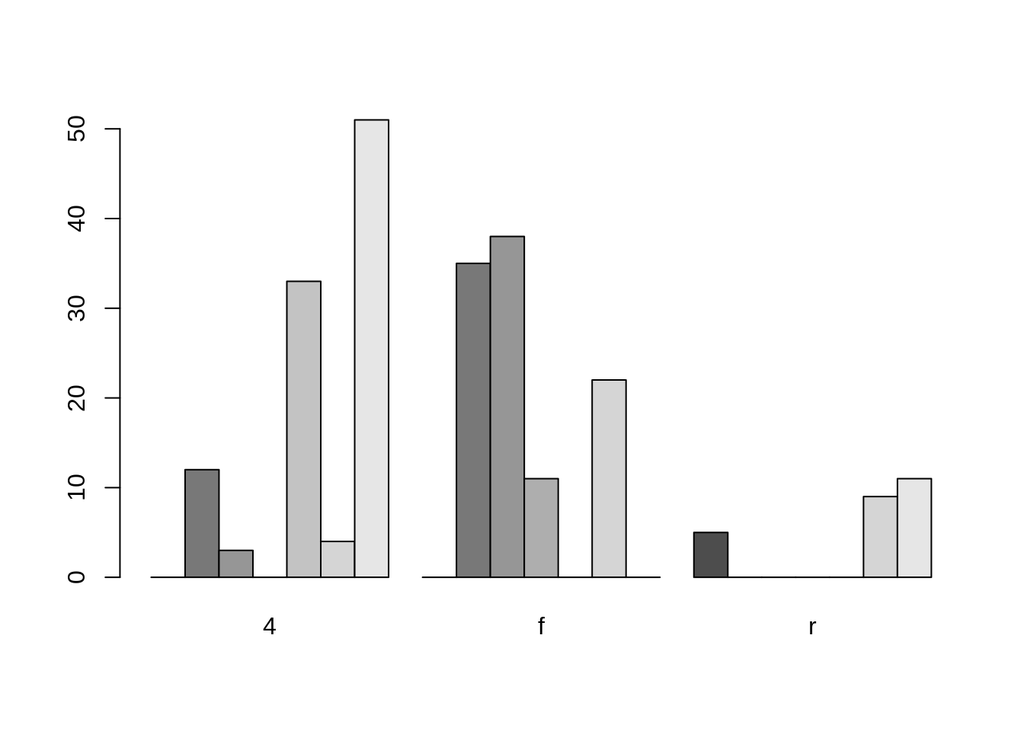

```r
counts2 <- table(mpg$class, mpg$drv)
barplot(counts2, beside = TRUE)
```

## Summary Statistics

The math part. For quantitative variables.

Three important things:

- Center: what’s normal in a dataset?
  - Mean, median and mode.

WHat do they “mean”? The story of the formula. Also interesting: there isn’t a “best” one.

Mean: Sum up, divide by the total #. **Meaning: mean gives the balancing point for the data.** Doesn’t always tell you what’ normal!

Median: **the middle.** In datasets with skew, the median can be a better measure of “normal”.

- Spread
- Shape